# Tarea 08 ANOVA

Heidy Valdelamar Gonzalez

2022-11-17

Llamamos librerías

```r
library(car)
library(emmeans)
library(rstatix)
library(tidyverse)
```

```r
library(ggplot2)
```

1. Se seleccionó una muestra aleatoria de los registros de nacimientos únicos de cada una de las cuatro poblaciones. Los pesos (gramos) de los bebés al nacer fueron los presentados en REV_C08_23.csv. ¿Proporcionan estos datos pruebas suficientes para indicar, con un nivel de α=.05 que las cuatro poblaciones difieren en cuanto al peso medio al nacer? Pruebe si hay una diferencia significativa entre todos los pares de medias posibles.

```r
PESO <- read_csv(file="REV_C08_23.csv", show_col_types = FALSE)
PESO
```

```
## # A tibble: 31 × 2
##    WEIGHT GROUP
##     <dbl> <chr>
##  1   2946 A
##  2   2913 A
##  3   2280 A
##  4   3685 A
##  5   2310 A
##  6   2582 A
##  7   3002 A
##  8   2408 A
##  9   3186 B
## 10   2857 B
## # … with 21 more rows
## # ℹ Use `print(n = ...)` to see more rows
```

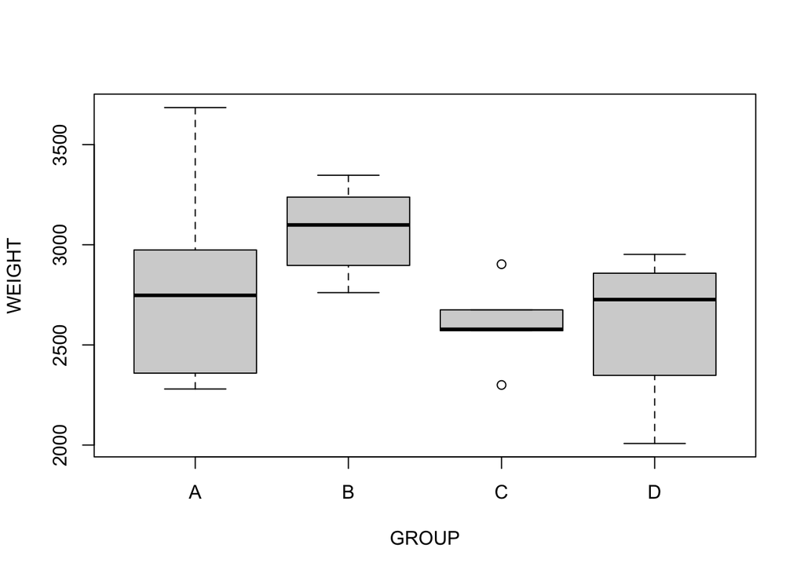

```r
boxplot(WEIGHT ~ GROUP, data = PESO)
```

```r
PESO_lm <- lm(WEIGHT~ GROUP, data = PESO)
(anova_PESO_lm <- anova(PESO_lm))
```

```
## Analysis of Variance Table
##
## Response: WEIGHT
##           Df  Sum Sq Mean Sq F value  Pr(>F)
## GROUP      3 1037901  345967  3.1185 0.04252 *
## Residuals 27 2995421  110942
## ---
## Signif. codes:  0 '***' 0.001 '**' 0.01 '*' 0.05 '.' 0.1 ' ' 1
```

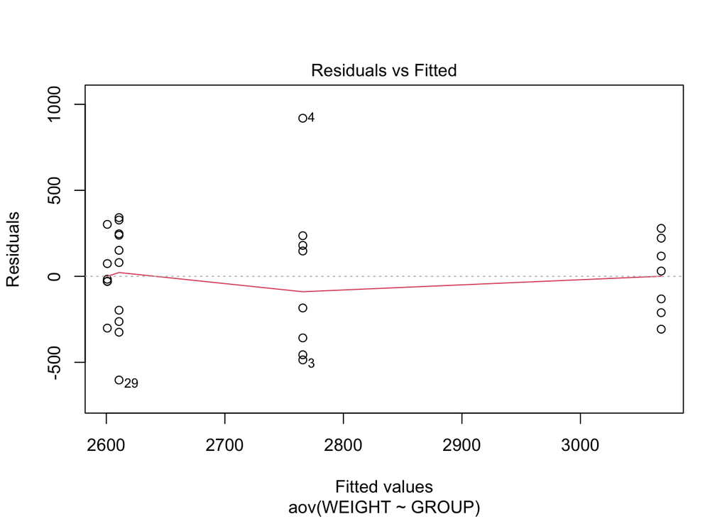

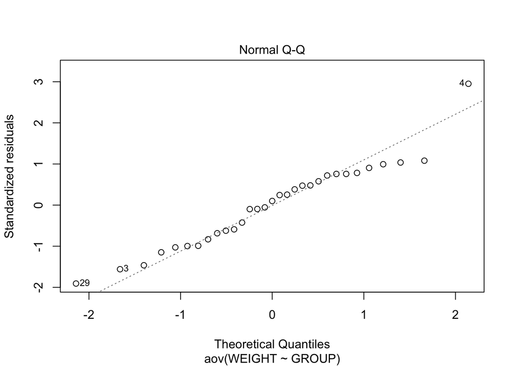

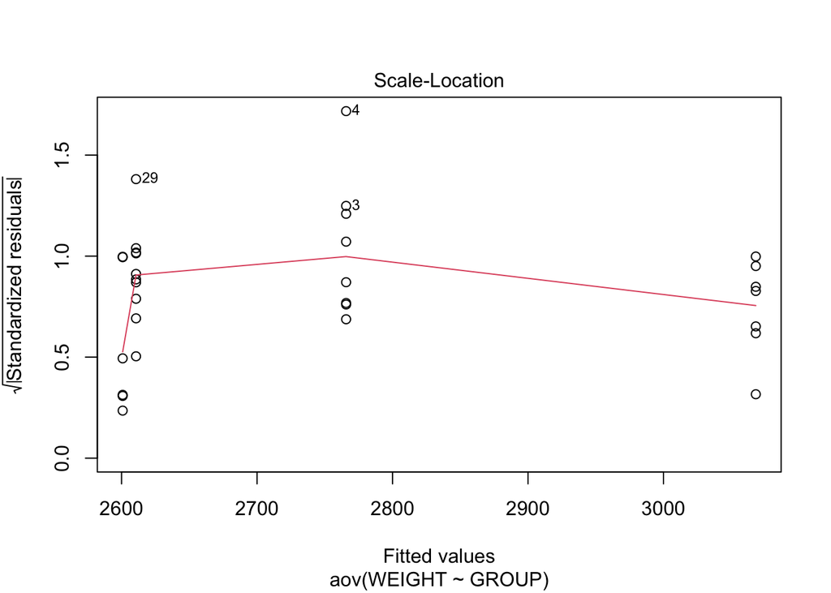

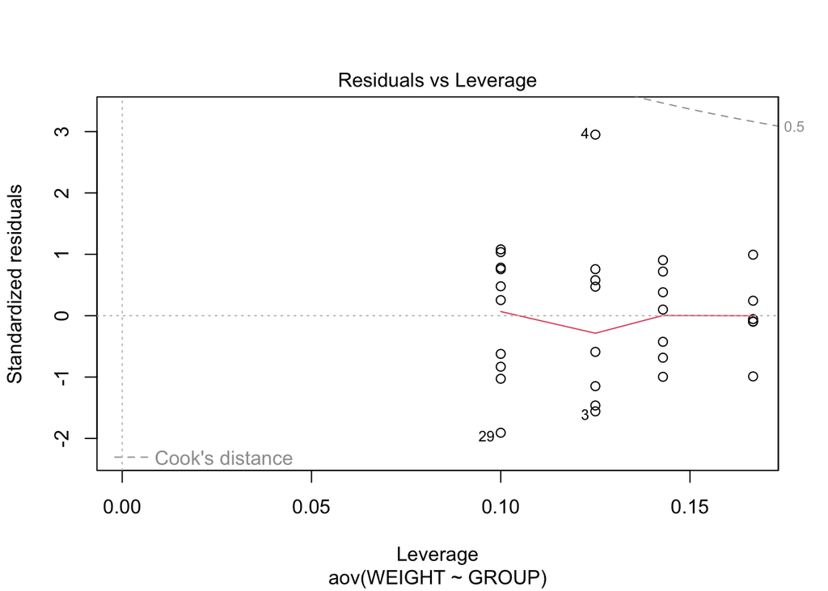

```r
PESO_aov <- aov(WEIGHT ~ GROUP, data = PESO)
plot(PESO_aov)
```

```r
TukeyHSD(PESO_aov)
```

```
##   Tukey multiple comparisons of means
##     95% family-wise confidence level
##
## Fit: aov(formula = WEIGHT ~ GROUP, data = PESO)
##
## $GROUP
##            diff       lwr        upr     p adj
## B-A  302.392857 -169.3488 774.134545 0.3167128
## C-A -164.916667 -657.1784 327.345025 0.7961143
## D-A -155.050000 -587.4084 277.308399 0.7611071
## C-B -467.309524 -974.4166  39.797554 0.0789696
## D-B -457.442857 -906.6308  -8.254923 0.0447701
## D-C    9.866667 -460.8255 480.558873 0.9999304
```

Sí hay una diferencia significativa entre los grupos.

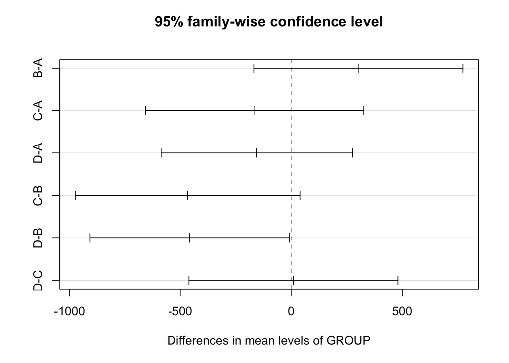

```r
plot(TukeyHSD(PESO_aov))
```

2. Un estudio realizado por Ikeda et al. se diseñó para determinar la dosis de bromuro de ipratropio en aerosol que mejora el rendimiento del ejercicio mediante ergometría progresiva en bicicleta en pacientes con enfermedad pulmonar obstructiva crónica estable. La edad media de los 20 sujetos masculinos era de 69,2 años, con una desviación estándar de 4,6 años. Entre los datos recogidos estaban los siguientes valores de ventilación máxima (VEmax,L/min) en el ejercicio máximo alcanzado para diferentes niveles de dosis de bromuro de ipratropio en REV_C08_46.csv.
1. Realice un análisis estadístico de los datos (que incluya la prueba de hipótesis y la construcción de intervalos de confianza) que, en su opinión, arroje información útil para los investigadores.
2. Determine los valores p para cada estadística de prueba calculada.
3. Indique todos los supuestos necesarios para validar su análisis.

```r
dosis <- read_csv(file="REV_C08_46.csv", show_col_types = FALSE)
dosis
```

```
## # A tibble: 20 × 5
##    Placebo   X40   X80  X160  X240
##      <dbl> <dbl> <dbl> <dbl> <dbl>
##  1      26    24    23    25    28
##  2      38    39    43    43    37
##  3      49    46    54    57    52
##  4      37    39    39    38    38
##  5      34    33    37    37    41
##  6      42    38    44    44    42
##  7      23    26    28    27    22
##  8      38    41    44    37    40
##  9      37    37    36    38    39
## 10      33    35    34    38    36
## 11      40    37    40    46    40
## 12      52    58    48    58    63
## 13      45    48    47    51    38
## 14      24    30    23    27    30
## 15      41    37    39    46    42
## 16      56    54    51    58    58
## 17      35    51    49    51    46
## 18      28    41    37    33    38
## 19      28    34    34    35    35
## 20      38    40    43    39    45
```

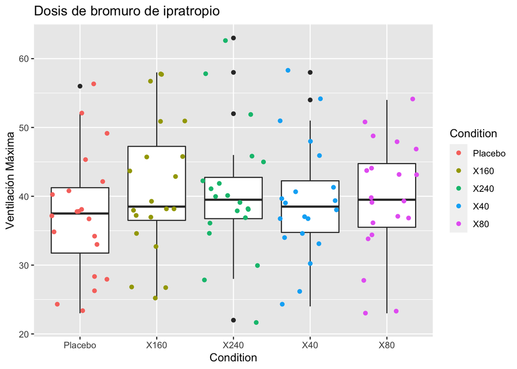

```r
dosis_long<-dosis%>%pivot_longer(cols=c("Placebo", "X40", "X80", "X160", "X240"), names_to = "Condition", values_to = "Index")

dosis_long %>%ggplot(aes(x = Condition, y = Index)) +geom_boxplot() +geom_jitter(aes(color = Condition)) +labs(y = "Ventilación Máxima",title = "Dosis de bromuro de ipratropio")
```

```r
pwc <- dosis_long%>%pairwise_t_test(Index~Condition, p.adjust.method = "bonferroni")
pwc
```

```
## # A tibble: 10 × 9
##    .y.   group1  group2    n1    n2     p p.signif p.adj p.adj.signif
##  * <chr> <chr>   <chr>  <int> <int> <dbl> <chr>    <dbl> <chr>
##  1 Index Placebo X160      20    20 0.15  ns           1 ns
##  2 Index Placebo X240      20    20 0.257 ns           1 ns
##  3 Index X160    X240      20    20 0.756 ns           1 ns
##  4 Index Placebo X40       20    20 0.449 ns           1 ns
##  5 Index X160    X40       20    20 0.491 ns           1 ns
##  6 Index X240    X40       20    20 0.704 ns           1 ns
##  7 Index Placebo X80       20    20 0.399 ns           1 ns
##  8 Index X160    X80       20    20 0.546 ns           1 ns
##  9 Index X240    X80       20    20 0.769 ns           1 ns
## 10 Index X40     X80       20    20 0.931 ns           1 ns
```

3. Holben et al. diseñaron un estudio para evaluar la ingesta de selenio en mujeres jóvenes en los años de la pubertad. Los investigadores estudiaron una cohorte de 16 mujeres durante tres veranos consecutivos. Una de las variables de resultado fue la ingesta diaria de selenio. Los investigadores examinaron los diarios dietéticos de los sujetos en el transcurso de dos semanas y luego calcularon la ingesta media diaria de selenio. La tabla en EXR_C08_S04_03.csv muestra los valores de la ingesta media diaria de selenio, para las 16 mujeres en los años 1, 2 y 3 del estudio. Estime la tabla ANOVA y calcule el valor p. Sea a=0,05

```r
ingesta <- read_csv(file="EXR_C08_S04_03.csv", show_col_types = FALSE)
ingesta
```

```
## # A tibble: 48 × 3
##    SEINTAKE  SUBJ  YEAR
##       <dbl> <dbl> <dbl>
##  1    113.      1     1
##  2    106.      2     1
##  3    102       3     1
##  4    104.      4     1
##  5    103.      5     1
##  6    113.      6     1
##  7    106.      7     1
##  8     83.6     8     1
##  9     95.0     9     1
## 10    113.     10     1
## # … with 38 more rows
## # ℹ Use `print(n = ...)` to see more rows
```

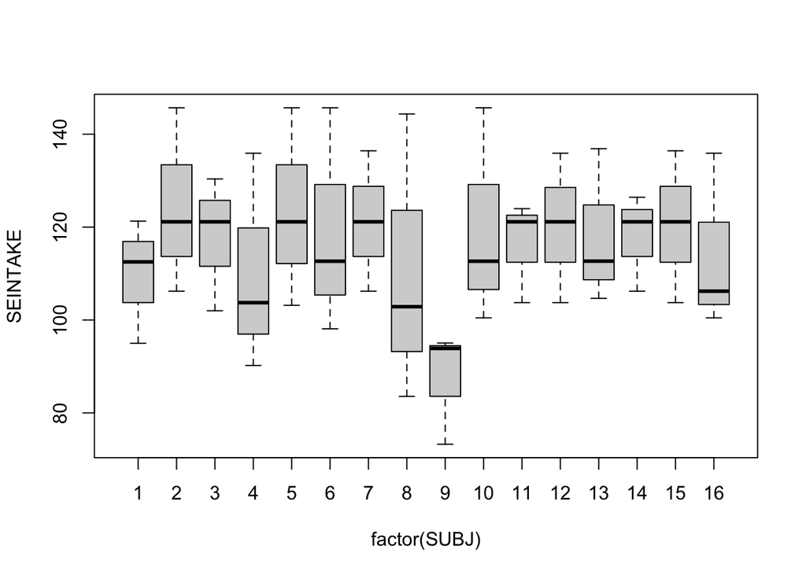

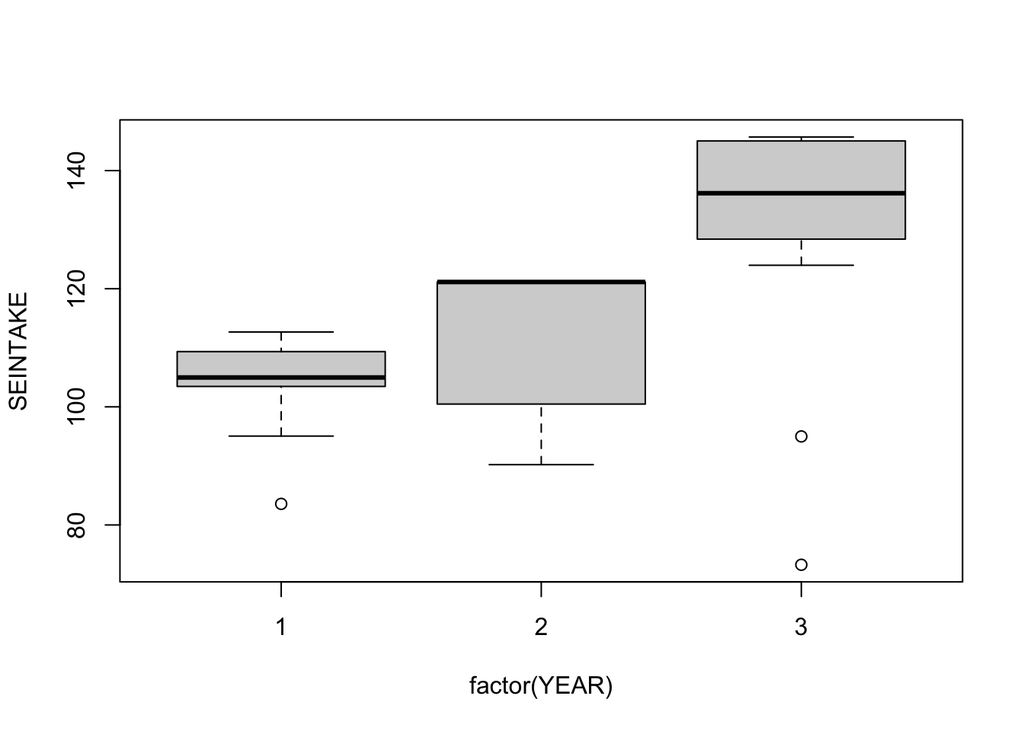

```r
plot(SEINTAKE~factor(SUBJ)+factor(YEAR), data=ingesta)
```

```r
ingesta <- ingesta %>%mutate(Treat=case_when(YEAR=="1"~"1YEAR",YEAR=="2"~"2YEAR",YEAR=="3"~"3YEAR"))

ingesta.aov <- aov(SEINTAKE~factor(SUBJ) + factor(YEAR), data=ingesta)

anova(ingesta.aov)
```

```
## Analysis of Variance Table
##
## Response: SEINTAKE
##              Df Sum Sq Mean Sq F value    Pr(>F)
## factor(SUBJ) 15 3451.1  230.07  1.2745    0.2767
## factor(YEAR)  2 5940.4 2970.19 16.4533 1.501e-05 ***
## Residuals    30 5415.7  180.52
## ---
## Signif. codes:  0 '***' 0.001 '**' 0.01 '*' 0.05 '.' 0.1 ' ' 1
```

```r
TukeyHSD(ingesta.aov)
```

```
##   Tukey multiple comparisons of means
##     95% family-wise confidence level
##
## Fit: aov(formula = SEINTAKE ~ factor(SUBJ) + factor(YEAR), data = ingesta)
##
## $`factor(SUBJ)`
##               diff        lwr       upr     p adj
## 2-1    14.75000000 -26.140218 55.640218 0.9900870
## 3-1     8.24333333 -32.646885 49.133552 0.9999863
## 4-1     0.36000000 -40.530218 41.250218 1.0000000
## 5-1    13.74000000 -27.150218 54.630218 0.9949917
## 6-1     9.22333333 -31.666885 50.113552 0.9999435
## 7-1    11.66333333 -29.226885 52.553552 0.9991058
## 8-1     0.67000000 -40.220218 41.560218 1.0000000
## 9-1   -22.19333333 -63.083552 18.696885 0.7949130
## 10-1   10.01000000 -30.880218 50.900218 0.9998468
## 11-1    6.69000000 -34.200218 47.580218 0.9999991
## 12-1   10.67000000 -30.220218 51.560218 0.9996746
## 13-1    8.47333333 -32.416885 49.363552 0.9999805
## 14-1    8.32666667 -32.563552 49.216885 0.9999844
## 15-1   10.84333333 -30.046885 51.733552 0.9996079
## 16-1    4.60000000 -36.290218 45.490218 1.0000000
## 3-2    -6.50666667 -47.396885 34.383552 0.9999994
## 4-2   -14.39000000 -55.280218 26.500218 0.9921488
## 5-2    -1.01000000 -41.900218 39.880218 1.0000000
## 6-2    -5.52666667 -46.416885 35.363552 0.9999999
## 7-2    -3.08666667 -43.976885 37.803552 1.0000000
## 8-2   -14.08000000 -54.970218 26.810218 0.9936339
## 9-2   -36.94333333 -77.833552  3.946885 0.1106739
## 10-2   -4.74000000 -45.630218 36.150218 1.0000000
## 11-2   -8.06000000 -48.950218 32.830218 0.9999898
## 12-2   -4.08000000 -44.970218 36.810218 1.0000000
## 13-2   -6.27666667 -47.166885 34.613552 0.9999996
## 14-2   -6.42333333 -47.313552 34.466885 0.9999995
## 15-2   -3.90666667 -44.796885 36.983552 1.0000000
## 16-2  -10.15000000 -51.040218 30.740218 0.9998192
## 4-3    -7.88333333 -48.773552 33.006885 0.9999923
## 5-3     5.49666667 -35.393552 46.386885 0.9999999
## 6-3     0.98000000 -39.910218 41.870218 1.0000000
## 7-3     3.42000000 -37.470218 44.310218 1.0000000
```

[output cut: 78 more lines]

```
## 14-12  -2.34333333 -43.233552 38.546885 1.0000000
## 15-12   0.17333333 -40.716885 41.063552 1.0000000
## 16-12  -6.07000000 -46.960218 34.820218 0.9999998
## 14-13  -0.14666667 -41.036885 40.743552 1.0000000
## 15-13   2.37000000 -38.520218 43.260218 1.0000000
## 16-13  -3.87333333 -44.763552 37.016885 1.0000000
## 15-14   2.51666667 -38.373552 43.406885 1.0000000
## 16-14  -3.72666667 -44.616885 37.163552 1.0000000
## 16-15  -6.24333333 -47.133552 34.646885 0.9999997
##
## $`factor(YEAR)`
##          diff       lwr      upr     p adj
## 2-1  6.690625 -5.020156 18.40141 0.3494010
## 3-1 26.221875 14.511094 37.93266 0.0000157
## 3-2 19.531250  7.820469 31.24203 0.0007985
```

4. Los investigadores de un centro de traumatología deseaban desarrollar un programa para ayudar a las víctimas de traumatismos cerebrales a recuperar un nivel aceptable de independencia. Se realizó un experimento con 72 sujetos con el mismo grado de daño cerebral. El objetivo era comparar diferentes combinaciones de tratamiento psiquiátrico y terapia física. Cada sujeto fue asignado a una de las 24 combinaciones diferentes de cuatro tipos de tratamiento psiquiátrico y seis programas de fisioterapia. Había tres sujetos en cada combinación. La variable de respuesta es el número de meses transcurridos entre el inicio de la terapia y el momento en que el paciente fue capaz de funcionar de forma independiente. Los resultados están en EXR_C08_S05_02.csv. ¿Se puede concluir sobre la base de estos datos que los diferentes programas de tratamiento psiquiátrico tienen efectos diferentes? ¿Se puede concluir que los programas de fisioterapia tienen una eficacia diferente? ¿Se puede concluir que existe una interacción entre los programas de tratamiento psiquiátrico y los programas de fisioterapia? Sea α=.05 para cada prueba.

```r
RES <- read.csv("EXR_C08_S05_02.csv")
RES
```

```
##    MONTHS PHYS PSYCH
## 1    11.0    1     A
## 2     9.6    1     A
## 3    10.8    1     A
## 4    10.5    2     A
## 5    11.5    2     A
## 6    12.0    2     A
## 7    12.0    3     A
## 8    11.5    3     A
## 9    11.8    3     A
## 10   11.5    4     A
## 11   11.8    4     A
## 12   10.5    4     A
## 13   11.0    5     A
## 14   11.2    5     A
```

[output cut: 58 more lines]

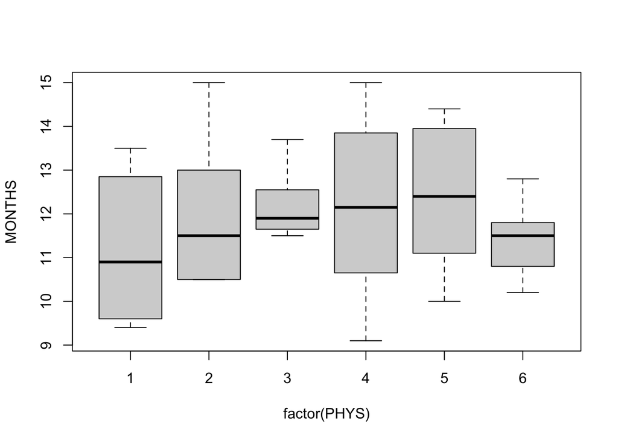

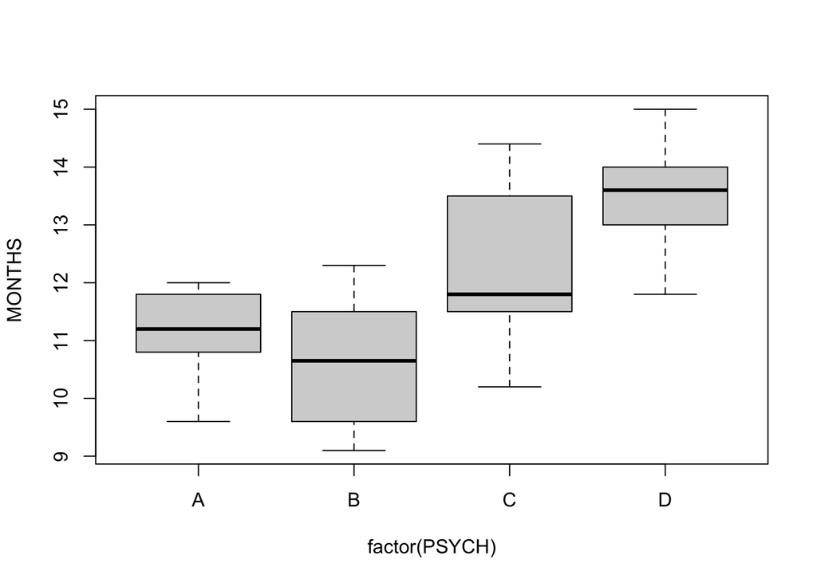

```r
plot(MONTHS~factor(PHYS)+factor(PSYCH), data=RES)
```

```r
RES <- RES %>%mutate(Treat=case_when(PSYCH=="A"~"APSYCH",PSYCH=="B"~"BPSYCH",PSYCH=="C"~"CPSYCH",PSYCH=="D"~"DPSYCH"))

RES.aov <- aov(MONTHS~factor(PHYS) + factor(PSYCH), data=RES)

anova(RES.aov)
```

```
## Analysis of Variance Table
##
## Response: MONTHS
##               Df Sum Sq Mean Sq F value    Pr(>F)
## factor(PHYS)   5 13.796  2.7592  3.5155  0.007251 **
## factor(PSYCH)  3 90.408 30.1359 38.3958 3.106e-14 ***
## Residuals     63 49.447  0.7849
## ---
## Signif. codes:  0 '***' 0.001 '**' 0.01 '*' 0.05 '.' 0.1 ' ' 1
```

```r
TukeyHSD(RES.aov)
```

```
##   Tukey multiple comparisons of means
##     95% family-wise confidence level
##
## Fit: aov(formula = MONTHS ~ factor(PHYS) + factor(PSYCH), data = RES)
##
## $`factor(PHYS)`
##           diff         lwr        upr     p adj
## 2-1  0.7333333 -0.32973087 1.79639754 0.3387739
## 3-1  0.9750000 -0.08806421 2.03806421 0.0903713
## 4-1  0.9500000 -0.11306421 2.01306421 0.1058524
## 5-1  1.1666667  0.10360246 2.22973087 0.0233739
## 6-1  0.1416667 -0.92139754 1.20473087 0.9987510
## 3-2  0.2416667 -0.82139754 1.30473087 0.9847898
## 4-2  0.2166667 -0.84639754 1.27973087 0.9907323
## 5-2  0.4333333 -0.62973087 1.49639754 0.8361267
## 6-2 -0.5916667 -1.65473087 0.47139754 0.5784178
## 4-3 -0.0250000 -1.08806421 1.03806421 0.9999998
## 5-3  0.1916667 -0.87139754 1.25473087 0.9947464
## 6-3 -0.8333333 -1.89639754 0.22973087 0.2078512
## 5-4  0.2166667 -0.84639754 1.27973087 0.9907323
## 6-4 -0.8083333 -1.87139754 0.25473087 0.2367687
## 6-5 -1.0250000 -2.08806421 0.03806421 0.0649975
##
## $`factor(PSYCH)`
##           diff        lwr       upr     p adj
## B-A -0.5444444 -1.3237558 0.2348669 0.2629568
## C-A  1.0388889  0.2595776 1.8182002 0.0044109
## D-A  2.3944444  1.6151331 3.1737558 0.0000000
## C-B  1.5833333  0.8040220 2.3626447 0.0000074
## D-B  2.9388889  2.1595776 3.7182002 0.0000000
## D-C  1.3555556  0.5762442 2.1348669 0.0001252
```

Sí hay una diferencia significativa entre los grupos.